# Regression in Matrix Form

[figure not shown]

## Reflection on Simple Linear Regression

We have learned that the simple linear regression model as

$$ Y_i = \beta_0 + \beta_1X_i + \epsilon_i $$ $$ \epsilon_i \overset{i.i.d}{\sim} N(0, \sigma^2) $$

We can use this model to explain the linear relationship between the independent variable and the dependent variable.

For instance,

How does the **emotion valence in news headlines** impact its **virality**?

## Dataset: Random Samples

1. U.S. Stock Futures Surge Amid Efforts to Recover from Tariff-Induced Volatility
2. Vice President J.D. Vance's 'Chinese Peasants' Remark Sparks International Backlash
3. Wes Welker Joins Washington Commanders Staff, Reuniting with Kliff Kingsbury
4. Florida Gators Clinch NCAA Men's Basketball Championship in Narrow Victory Over Houston Cougars
5. New Insights on Dementia: Declining Age-Specific Rates and Promising Treatments Offer Hope

| index | Valence | Virality |
| --- | --- | --- |
| 0 | -1 | 3 |
| 1 | 0 | 1 |
| 2 | -3 | 5 |
| 3 | 2 | 0 |
| 4 | 1 | 1 |

## Linear Regression Model

What is the relationship between these two variables? We can draw the scatterplot shown below.

[figure not shown]

## Simple Linear Regression

We will have $Y_i = \beta_0 + \beta_1 * X_i + \epsilon_i$, and we can use the **OLS** method to estimate for the parameter $\beta_0$ and $\beta_1$.

$$ \hat{\beta_1} = \frac{\sum (X_i-\bar{X})(Y_i-\bar{Y})}{\sum (X_i-\bar{X})^2} \ \ \ \ \ \ \ \ \hat{\beta_0} = \bar{Y} - b_1 \bar{X} $$

And then we can conduct the t-tests based on the following table for these two statistics.

|  | $b_0$ | $b_1$ |
| --- | --- | --- |
| $s.e.$ | $\sqrt{MSE(\frac{1}{n} + \frac{\bar{X}^2}{\sum (X_i-\bar{X})^2})}$ | $\sqrt{MSE \frac{1}{\sum (X_i -\bar{X})^2}}$ |
| $T$ Statistic | $T_{\beta_0}= \frac{\bar{Y} - b_1 \bar{X}}{\sqrt{MSE(\frac{1}{n} + \frac{\bar{X}^2}{\sum (X_i-\bar{X})^2})}}$ | $T_{\beta_1}= \frac{\frac{\sum (X_i-\bar{X})(Y_i-\bar{Y})}{\sum (X_i-\bar{X})^2}}{\sqrt{MSE \frac{1}{\sum (X_i -\bar{X})^2}}}$ |

## Simple Linear Regression in Matrix form

Now, the question is that:

1. Is there exists a simpler format to represent these formulas?
2. What if we have additional independent variables to be added into the model?

We need to use Matrix to represent our model and data.

The question is how?

## Simple Linear Regression in Matrix form

We can express the following model for each of our sample.

$$ \begin{align} Y_1 = \beta_0*1 + \beta_1 * X_1 + \epsilon_1 \\ Y_2 = \beta_0*1 + \beta_1 * X_2 + \epsilon_2 \\ Y_3 = \beta_0*1 + \beta_1 * X_3 + \epsilon_3 \\ Y_4 = \beta_0*1 + \beta_1 * X_4 + \epsilon_4 \\ Y_5 = \beta_0*1 + \beta_1 * X_5 + \epsilon_5 \end{align} $$

By doing so, we can represent these equations into vectors and matrix.

## Response Vector, Regression Vector and Error Vector

On the left side, we can express the random samples $Y_i$ as a vector of random variables $\boldsymbol{Y}_{N\times 1}$.

$$ \boldsymbol{Y}_{5\times 1}=\begin{bmatrix} Y_1 \\ Y_2 \\ Y_3 \\ Y_4 \\ Y_5 \end{bmatrix} $$

On the right side, we can express it as the sum of two vectors, the regression vector and the **Error Vector** $\boldsymbol{\epsilon}_{N\times 1}$.

$$ \begin{bmatrix} Y_1 \\ Y_2 \\ Y_3 \\ Y_4 \\ Y_5 \end{bmatrix} = \begin{bmatrix} \beta_0 * 1 + \beta_1 * X_1 \\ \beta_0 * 1 + \beta_1 * X_2 \\ \beta_0 * 1 + \beta_1 * X_3 \\ \beta_0 * 1 + \beta_1 * X_4 \\ \beta_0 * 1 + \beta_1 * X_5 \end{bmatrix} + \begin{bmatrix} \epsilon_1 \\ \epsilon_2 \\ \epsilon_3 \\ \epsilon_4 \\ \epsilon_5 \end{bmatrix} $$

## Design matrix and Coefficient Vector

How can we better represent the vector of the regression model $\beta_0 * 1 + \beta_1*X$?

For each of the sample, we can write the regression model as a inner product between two vectors:

$$ \beta_0 * 1 + \beta_1 * X_1 = [1\ \ X_1] \begin{bmatrix} \beta_0 \\ \beta_1 \end{bmatrix} = \vec{X_1}^T\vec{\beta} $$

## Design matrix and Coefficient Vector

Now, lets consider the inner product between regression parameters and independent variables for all of the $N$ samples.

We can construct a matrix for all independent variables, called **Design Matrix** $\boldsymbol{X}$.

$$ \boldsymbol{X}_{N \times 2} = \begin{bmatrix} 1 & X_1 \\ 1 & X_2 \\ 1 & X_3 \\ 1 & X_4 \\ 1 & X_5 \end{bmatrix}_{5 \times 2} $$

And the vector of regression parameters including intercept $\beta_0$ and slope $\beta_1$, called **Coeffcient Vector** $\boldsymbol{\beta}$

$$ \boldsymbol{\beta}_{2 \times 1} = \begin{bmatrix} \beta_0 \\ \beta_1\end{bmatrix} $$

## Regression Model in Matrix form

It turns out the regression model vector can be expressed as the product of the design matrix and the coefficient vector:

$$ \begin{bmatrix} \beta_0 * 1 + \beta_1 * X_1 \\ \beta_0 * 1 + \beta_1 * X_2 \\ \beta_0 * 1 + \beta_1 * X_3 \\ \beta_0 * 1 + \beta_1 * X_4 \\ \beta_0 * 1 + \beta_1 * X_5 \end{bmatrix}_{5 \times 1} = \begin{bmatrix} 1 & X_1 \\ 1 & X_2 \\ 1 & X_3 \\ 1 & X_4 \\ 1 & X_5 \end{bmatrix}_{5 \times 2} \begin{bmatrix} \beta_0 \\ \beta_1\end{bmatrix}_{2 \times 1} = \boldsymbol{X} \boldsymbol{\beta} $$

Thus, taken together, the **matrix form** of simple linear regression is

$$ \boldsymbol{Y}_{N\times1} = \boldsymbol{X}_{N \times 2}\boldsymbol{\beta}_{2 \times 1} + \boldsymbol{\epsilon}_{N\times 1} $$

And it assumes:

$$ \boldsymbol{E[\epsilon]} = \boldsymbol{0} \ \ \ \ \ \ \boldsymbol{\sigma^2\{\epsilon\}}=\sigma^2 \boldsymbol{I} $$

## Regression assumption in matrix form

The regression assumption as we have learned before is

$$ \epsilon_i \overset{i.i.d}{\sim} N(0, \sigma^2) $$

It means that $E[\epsilon_i]=0$ and $\sigma^2\{\epsilon_i\}=\sigma^2$ and $Cov(\epsilon_i, \epsilon_j)=0$

Thus, we would have

$$ \boldsymbol{E[\epsilon]} = \begin{bmatrix} E[\epsilon_1] \\ E[\epsilon_2] \\ E[\epsilon_3]\\ E[\epsilon_4]\\ E[\epsilon_5] \end{bmatrix}_{5 \times 1} = \begin{bmatrix} 0 \\ 0 \\ 0 \\ 0 \\ 0 \end{bmatrix}_{5 \times 1} = \boldsymbol{0}_{5\times1} $$

## Regression assumption in matrix form

We can also construct the Variance-Covariance Matrix for $\epsilon_i$ and $Y_i$

$$ \boldsymbol{\sigma^2\{\epsilon\}} = \begin{bmatrix} Var(\epsilon_1) & Cov(\epsilon_1, \epsilon_2) & Cov(\epsilon_1, \epsilon_3) & Cov(\epsilon_1, \epsilon_4) & Cov(\epsilon_1, \epsilon_5) \\ Cov(\epsilon_1, \epsilon_2) & Var(\epsilon_2) & Cov(\epsilon_2, \epsilon_3) & Cov(\epsilon_2, \epsilon_4) & Cov(\epsilon_2, \epsilon_5) \\ Cov(\epsilon_1, \epsilon_3) & Cov(\epsilon_2, \epsilon_3) & Var(\epsilon_3) & Cov(\epsilon_3, \epsilon_4) & Cov(\epsilon_3, \epsilon_5) \\ Cov(\epsilon_1, \epsilon_4) & Cov(\epsilon_2, \epsilon_4) & Cov(\epsilon_3, \epsilon_4) & Var(\epsilon_4) & Cov(\epsilon_4, \epsilon_5) \\ Cov(\epsilon_1, \epsilon_5) & Cov(\epsilon_2, \epsilon_5) & Cov(\epsilon_3, \epsilon_5) & Cov(\epsilon_4, \epsilon_5) & Var(\epsilon_5) \end{bmatrix}_{5 \times 5} = \begin{bmatrix} \sigma^2 & 0 & 0 & 0 & 0 \\ 0 & \sigma^2 & 0 & 0 & 0 \\ 0 & 0 & \sigma^2 & 0 & 0 \\ 0 & 0 & 0 & \sigma^2 & 0 \\ 0 & 0 & 0 & 0 & \sigma^2 \\ \end{bmatrix}_{5 \times 5} = \sigma^2 \boldsymbol{I}_{N\times1} $$

$$ \boldsymbol{\sigma^2\{Y\}} = \boldsymbol{\sigma^2\{X\beta+\epsilon\}} = \boldsymbol{\sigma^2\{\epsilon\}} = \sigma^2 \boldsymbol{I}_{N\times1} $$

## Mean Response Vector

The mean response of the regression model $\hat{Y_i} = E[Y_i] = \beta_0 + \beta_1 X$ can be constructed in vector form as well

$$ \boldsymbol{E[Y]} = \boldsymbol{X}\boldsymbol{\beta} $$

$$ \begin{bmatrix} E[Y_1] \\ E[Y_2] \\ E[Y_3] \\ E[Y_4] \\ E[Y_5] \end{bmatrix}_{5 \times 1} = \begin{bmatrix} \beta_0 * 1 + \beta_1 X_1 \\ \beta_0 * 1 + \beta_1 X_2 \\ \beta_0 * 1 + \beta_1 X_3 \\ \beta_0 * 1 + \beta_1 X_4 \\\beta_0 * 1 + \beta_1 X_5 \end{bmatrix}_{5 \times 1} \\ = \begin{bmatrix} 1 & X_1 \\ 1 & X_2 \\ 1 & X_3 \\ 1 & X_4 \\ 1 & X_5 \end{bmatrix}_{5 \times 2} \begin{bmatrix} \beta_0 \\ \beta_1 \end{bmatrix}_{2 \times 1} $$

## Summary: Regression Model in Matrix Form

1. Simple Regression in matrix form

   $\boldsymbol{Y}_{N\times1} = \boldsymbol{X}_{N\times2} \boldsymbol{\beta}_{2\times1}+ \boldsymbol{\epsilon}_{N\times1}$
2. The random error is a random vector $\boldsymbol{\epsilon}_{N\times1}$ with

   $\boldsymbol{E[\epsilon]} = \boldsymbol{0}_{N\times1}$, and $\boldsymbol{\sigma^2\{\epsilon\}} = \sigma^2\boldsymbol{I}_{N\times N}$
3. Normal Error model

   $\boldsymbol{\epsilon} \sim Normal_n(\boldsymbol{0}, \sigma^2\boldsymbol{I}_{N\times N})$
4. For the mean response vector

   $\boldsymbol{E[Y]} = \boldsymbol{X}\boldsymbol{\beta}$, and $\boldsymbol{\sigma^2\{Y\}}=\sigma^2\boldsymbol{I}$

## OLS Point Estimate for Regression Intercept and Slope

Using regular expression, we have shown that the best estimates for regression parameters is to minimize the **sum of squared residuals**, called the **ordinary least squares** method.

[figure not shown]

## OLS in matrix form

What OLS does is to find the parameter estimate $b_0$ and $b_1$, which minimizes

$$ Q(b_0, b_1) = \sum_{i}^N (Y_i - b_0 - b_1 X_i)^2 $$

In matrix form, we have learned that the sum of squres is the inner product of the vector with itself

$$ \sum X_i^2 = \vec{X}^T \vec{X} $$

Additionally, we consider the point estimate as a vector to be estimated as $\boldsymbol{b} = \begin{bmatrix} b_0 \\ b_1 \end{bmatrix}$

Thus, the function to be minimized is essentially

$$ Q(b_0, b_1) = (\boldsymbol{Y} - \boldsymbol{X}\boldsymbol{b})^T(\boldsymbol{Y} - \boldsymbol{X}\boldsymbol{b}) = \boldsymbol{Y^T Y - b^TX^TY - Y^TXb +b^TX^TXb} $$

## Find OLS Coefficient Vector

Finding the regression coefficient estimates vector $\boldsymbol{b}$ requires a bit calculus, which is skipped in this class

But similar to what we have done previously, we can derive the normal equation

$$ \boldsymbol{X^TXb = X^TY} $$

In regular expression, from what we have learned, this is equivalent to

$$ \sum Y_i = n\hat{\beta_0} + \hat{\beta_1}\sum X_i $$ $$ \sum X_i Y_i = \hat{\beta_0} \sum X_i + \hat{\beta_1}\sum X_i^2 $$

## Find OLS Coefficient Vector by solving the normal equation

How do we solve this equation to get $\boldsymbol{b}$?

We left multiply $\boldsymbol{(X^TX)^{-1}}$ on both side of the equation

$$ \boldsymbol{(X^TX)^{-1}X^TXb = (X^TX)^{-1}X^TY} $$

Given that $\boldsymbol{(X^TX)^{-1}X^TX = I}$

We will have

$$ \boldsymbol{Ib=(X^TX)^{-1}X^TY} $$ Thus

$$ \boldsymbol{b = (X^TX)^{-1}X^TY} = \begin{bmatrix} \bar{Y}-b_1\bar{X} \\ \frac{\sum(X_i-\bar{X})(Y_i-\bar{Y})}{\sum (X_i -\bar{X})^2} \end{bmatrix} $$

## Practice

Now, let's solve this with the example we have shown above

| index | Valence | Virality |
| --- | --- | --- |
| 0 | -1 | 3 |
| 1 | 0 | 1 |
| 2 | -3 | 5 |
| 3 | 2 | 0 |
| 4 | 1 | 1 |

1. Construct the design matrix $\boldsymbol{X}$ and the response variable vector $\boldsymbol{Y}$
2. Calculate $\boldsymbol{X^TX}$
3. Calculate $\boldsymbol{(X^TX)^{-1}}$, recall that $\begin{bmatrix} a & b \\ c & d \end{bmatrix} ^{-1} = \frac{1}{ad-bc}\begin{bmatrix}d & -b \\ -c & a\end{bmatrix}$
4. Calculate $\boldsymbol{X^TY}$
5. Calculate $\boldsymbol{b=(X^TX)^{-1}X^TY}$

## Expected value and Variance of coefficient

We have shown that $\boldsymbol{b = (X^TX)^{-1}X^TY}$

Because in regression model, we assume $\boldsymbol{X}$ is know values, thus the matrix $\boldsymbol{(X^TX)^{-1}X^T}$ is a known matrix.

Thus, we can consider the regression coefficient $\boldsymbol{b}$ as a product of a known matrix $\boldsymbol{(X^TX)^{-1}X^T}$ and the random variable vector $\boldsymbol{Y}$.

Or in other words, we can consider $\boldsymbol{b}$ as a linear combination of $\boldsymbol{Y}$, or as a linear transformation of $\boldsymbol{Y}$ by the matrix $\boldsymbol{(X^TX)^{-1}X^T}$.

We assume that $\boldsymbol{Y}$ follows normal distributions under the normal error model, and it implies that $\boldsymbol{b}$ also follows a normal distribution.

Now the question is, what is the expected value and variance-covariance of the coefficient vector $\boldsymbol{b}$, so that we can use them for statistical significance testing?

## Expected value and Variance of random vector

First, we need to learn about some rules of expected value and variance of random variables in matrix form.

In regular form, we have learned that for a random variable $X$ and a constant $a$

$$ \begin{align} E[aX] &= aE[X] \\ Var(aX) &= a^2Var(X) \end{align} $$

Now, in matrix form, for a random variable vector $\boldsymbol{X}_{r\times 1}$ and a known matrix $\boldsymbol{A}_{s\times r}$, we will have

$$ \begin{align} \boldsymbol{E[AX]} &= \boldsymbol{AE[X]} \\ \boldsymbol{\sigma^2\{AX\}} &= \boldsymbol{A\sigma^2\{X\}A^T} \end{align} $$

## Expected value of Coeffcient vector

Now, we can start working on the expected value and the variance-covariance of the coefficient vector $\boldsymbol{b}$.

$$ \begin{align} \boldsymbol{E[b]} &= \boldsymbol{E[(X^TX)^{-1}X^TY]} \\ &= \boldsymbol{(X^TX)^{-1}X^TE[Y]} \\ &= \boldsymbol{(X^TX)^{-1}X^TX\beta} \ \ \ \ \ \ \ \ \ \text{given that $\boldsymbol{E[Y]=X\beta}$} \\ &= \boldsymbol{I\beta} = \boldsymbol{\beta} \ \ \ \ \ \ \ \ \ \ \ \ \text{Given that $\boldsymbol{(X^TX)^{-1}X^TX=I}$} \end{align} $$

## Variance-Covariance of coefficient vector

What about the variance-covariance of the coefficient vector $\boldsymbol{b}$?

$$ \begin{align} \boldsymbol{\sigma^2\{b\}} &= \boldsymbol{\sigma^2\{(X^TX)^{-1}X^TY\}} \\ &= \boldsymbol{(X^TX)^{-1}X^T \sigma^2\{Y\} ((X^TX)^{-1}X^T)^T} \\ &= \boldsymbol{(X^TX)^{-1}X^T \sigma^2\{Y\} ((X^TX)^{-1}X^T)^T} \\ &= \boldsymbol{(X^TX)^{-1}X^T} \sigma^2 \boldsymbol{I ((X^TX)^{-1}X^T)^T} \ \ \ \ \ \ \ \ \ \text{given that $\boldsymbol{Y} = \sigma^2\boldsymbol{I}$} \\ &= \sigma^2 \boldsymbol{(X^TX)^{-1}X^T((X^TX)^{-1}X^T)^T} \\ &= \sigma^2 \boldsymbol{(X^TX)^{-1}X^TX(X^TX)^{-1}} \\ &= \sigma^2 \boldsymbol{(X^TX)^{-1}} \ \ \ \ \ \ \ \ \text{given that $\boldsymbol{(X^TX)^{-1}X^TX} = \boldsymbol{I}$} \\ &= \sigma^2 \begin{bmatrix} \frac{1}{n}+\frac{\bar{X}^2}{\sum(X_i-\bar{X})^2} & -\frac{\bar{X}}{\sum(X_i-\bar{X})^2} \\ -\frac{\bar{X}}{\sum(X_i-\bar{X})^2} & \frac{1}{\sum (X_i-\bar{X})^2} \end{bmatrix} \end{align} $$

Thus, we can conduct $t$ test using $\hat{\sigma^2} = MSE = \boldsymbol{(Y-Xb)^T(Y-Xb)}/(n-2)$

## Mean Response Vector and Hat Matrix

We have shown that $\boldsymbol{b = (X^TX)^{-1}X^TY}$, thus it is pretty straightforward to derive the mean response vector for dependent variable $\boldsymbol{\hat{Y}}$

$$ \boldsymbol{\hat{Y}} = \boldsymbol{Xb} = \boldsymbol{X(X^TX)^{-1}X^TY} $$

Note that the predicted value of $\boldsymbol{\hat{Y}}$ on the regression line is just a linear transformation or project of the actual observed samples $\boldsymbol{Y}$, by the projection matrix $\boldsymbol{X(X^TX)^{-1}X^T}$.

We define this project matrix as the **Hat Matrix** $\boldsymbol{H}$, because it transforms observed data $\boldsymbol{Y}$ into estimated values $\boldsymbol{\hat{Y}}$

$$ \boldsymbol{H} = \boldsymbol{X(X^TX)^{-1}X^T} $$ $$ \boldsymbol{\hat{Y}} = \boldsymbol{HY} $$

## ANOVA test in matrix form

Just like in regular form, we can express the $F$ test in matrix form as well.

We need to calcualte $SSR$, $SSE$, $SSTO$, and $MSR$, $MSE$

$$ \begin{align} \boldsymbol{e} &= \boldsymbol{Y-\hat{Y}} = \boldsymbol{Y - HY} = \boldsymbol{(I-H)Y} \\ SSE &= \boldsymbol{e^Te} = \boldsymbol{Y^T(I-H)^T(I-H)Y} = \boldsymbol{Y^T(I-H)Y} \\ MSE &= \frac{SSE}{df(SSE)} = \frac{SSE}{n-2} \\ SSTO &= \sum(Y_i-\bar{Y})^2 = \sum(Y_i)^2 - n\bar{Y}^2 \\ &= \boldsymbol{Y^TY}-\frac{1}{n}\boldsymbol{Y^TJY} = \boldsymbol{Y^T(I-\frac{1}{n}J)Y} \end{align} $$

The $\boldsymbol{J}$ matrix is the square matrix with all 1 in its entries $$ \boldsymbol{J} = \begin{bmatrix} 1& 1& ... & 1\\ 1& 1& ... & 1\\ ... & ... & ... & ...\\ 1& 1& ... & 1 \end{bmatrix} $$

## Research Example: Negativity Bias in News Headlines

### Negativity Bias

When you are browsing a news website and searching for which news you want to read, **negativity bias** means that people are biased to choose negative news (bad news) as compared to positive news (good news).

Which news you want to read?

[figure not shown]

## Research example

[figure not shown]

## Dataset introduction: Upworthy

[figure not shown]

## Dataset introduction: Upworthy Archive

**A/B Testing**

[figure not shown]

## Dataset introduction: Upworthy Archive

The [upworthy archive dataset](https://upworthy.natematias.com/about-the-archive.html) contains 128,217 of such a/b testing results.

The dependent variable in this dataset will be **Click Through Rate**, which measures the probability of people clicking on the news after viewing the headline as a measure of the attractiveness of the news headline.

$$ Click\_Through\_Rate = \frac{\#\ Clicks}{\#\ Impressions} $$

What are the independent variables?

It is a set of computationally measured language features using Natural Language Processing techniques.

## Hypothesis of Negativity Bias

Now, lets just keep it simple. We want to test the negaitivty bias hypothesis.

We focuse on the percentage of negative words in the headline to be associated with the click-through-rate of the headline.

$$ Click\_Through\_Rate_i = \beta_0 + \beta_1 * Percentage\_Negative\_Words_i + \epsilon_i $$ $$ \epsilon_i \sim N(0, \sigma^2) $$

Now lets start analyze the data!

## Load packages

```python
import pandas as pd
import numpy as np
import seaborn as sns
from matplotlib import pyplot as plt
from statsmodels.tools.tools import add_constant
from scipy import stats
```

## Load Data

```python
df = pd.read_csv("./data/negativity_bias_regression_df.csv")
df[["liwc_negemo", "click_rate"]].head()
```

|  | liwc_negemo | click_rate |
| --- | --- | --- |
| 0 | 0.000000 | 0.013271 |
| 1 | 0.000000 | 0.010049 |
| 2 | 0.052632 | 0.009615 |
| 3 | 0.047619 | 0.028881 |
| 4 | 0.000000 | 0.007744 |

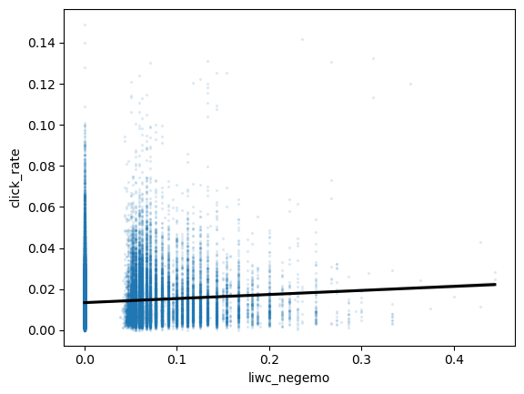

```python
sns.regplot(x=df.liwc_negemo, y=df.click_rate, scatter_kws={"alpha":0.1, "s":2}, line_kws={"color": "black"})
```

## Design Matrix

```python
X = df.liwc_negemo.to_numpy()
X = add_constant(X)
print(X.shape)
X
```

```
(53699, 2)
```

```
array([[1.        , 0.        ],
       [1.        , 0.        ],
       [1.        , 0.05263158],
       ...,
       [1.        , 0.05263158],
       [1.        , 0.        ],
       [1.        , 0.        ]])
```

## Response Vector

```python
Y = df.click_rate.to_numpy()
print(Y.shape)
```

```
(53699,)
```

## OSL point estimate

```python
b = np.linalg.inv(X.T @ X) @ X.T @ Y
b0 = b[0]
b1 = b[1]
print(b)
```

```
[0.01338262 0.0198131 ]
```

## Variance Covariance Matrix of Coefficients

```python
Y_hat = X @ b
Y_hat
e = Y-Y_hat
SSE = e.T @ e
df_SSE = Y.shape[0]-2
MSE = SSE/df_SSE
```

```python
SSTO = (Y-Y.mean()).T @ (Y-Y.mean())
df_SSTO = Y.shape[0] - 1
SSR = SSTO - SSE
MSR = SSR/1
r_2 = SSR/SSTO
```

## Standard Error of Coefficients

```python
sigma_2_b = MSE * np.linalg.inv(X.T @ X)

sigma_2_b0 = sigma_2_b.diagonal()[0]
sigma_2_b1 = sigma_2_b.diagonal()[1]

se_b0 = np.sqrt(sigma_2_b0)
se_b1 = np.sqrt(sigma_2_b1)
```

## T statistics of Coefficients

```python
t_b0 = b0/se_b0
t_b1 = b1/se_b1
print(t_b0)
print(t_b1)
```

```
229.48586976815125
17.707484066348993
```

## p values of Coefficients

```python
p_b0 = 2*(1-stats.t.cdf(t_b0, df=df_SSE))
p_b1 = 2*(1-stats.t.cdf(t_b1, df=df_SSE))
print(p_b0)
print(p_b1)
```

```
0.0
0.0
```

## Fit the model using `statsmodel` package

```python
import statsmodels.api as sm
import statsmodels.formula.api as smf

results = sm.OLS(Y, X).fit()
results.summary().tables[0]
```

OLS Regression Results

| Dep. Variable: | y | R-squared: | 0.006 |
| --- | --- | --- | --- |
| Model: | OLS | Adj. R-squared: | 0.006 |
| Method: | Least Squares | F-statistic: | 313.6 |
| Date: | Wed, 09 Apr 2025 | Prob (F-statistic): | 5.81e-70 |
| Time: | 17:43:55 | Log-Likelihood: | 1.6380e+05 |
| No. Observations: | 53699 | AIC: | -3.276e+05 |
| Df Residuals: | 53697 | BIC: | -3.276e+05 |
| Df Model: | 1 |  |  |
| Covariance Type: | nonrobust |  |  |

```python
results.summary().tables[1]
```

[output not shown]

```python
results = smf.ols('click_rate ~ liwc_negemo', data=df).fit()
results.summary().tables[0]
```

OLS Regression Results

| Dep. Variable: | click_rate | R-squared: | 0.006 |
| --- | --- | --- | --- |
| Model: | OLS | Adj. R-squared: | 0.006 |
| Method: | Least Squares | F-statistic: | 313.6 |
| Date: | Wed, 09 Apr 2025 | Prob (F-statistic): | 5.81e-70 |
| Time: | 17:43:48 | Log-Likelihood: | 1.6380e+05 |
| No. Observations: | 53699 | AIC: | -3.276e+05 |
| Df Residuals: | 53697 | BIC: | -3.276e+05 |
| Df Model: | 1 |  |  |
| Covariance Type: | nonrobust |  |  |

```python
results.summary().tables[1]
```

|  | coef | std err | t | P>\|t\| | [0.025 | 0.975] |
| --- | --- | --- | --- | --- | --- | --- |
| Intercept | 0.0134 | 5.83e-05 | 229.486 | 0.000 | 0.013 | 0.013 |
| liwc_negemo | 0.0198 | 0.001 | 17.707 | 0.000 | 0.018 | 0.022 |